# R Notebook

# 9.6.3 Lollipop plot-2

```
## Gene: PML
```

```
## 9 transcripts available. Use arguments refSeqID or proteinID to manually specify tx name.
```

```
##    HGNC refseq.ID protein.ID aa.length
## 1:  PML NM_033238  NP_150241       882
## 2:  PML NM_002675  NP_002666       633
## 3:  PML NM_033249  NP_150252       585
## 4:  PML NM_033247  NP_150250       435
## 5:  PML NM_033239  NP_150242       829
## 6:  PML NM_033250  NP_150253       781
## 7:  PML NM_033240  NP_150243       611
## 8:  PML NM_033244  NP_150247       560
## 9:  PML NM_033246  NP_150249       423
```

```
## Using longer transcript NM_033238 for now.
## 9 transcripts available. Use arguments refSeqID or proteinID to manually specify tx name.
```

```
##    HGNC refseq.ID protein.ID aa.length
## 1:  PML NM_033238  NP_150241       882
## 2:  PML NM_002675  NP_002666       633
## 3:  PML NM_033249  NP_150252       585
## 4:  PML NM_033247  NP_150250       435
## 5:  PML NM_033239  NP_150242       829
## 6:  PML NM_033250  NP_150253       781
## 7:  PML NM_033240  NP_150243       611
## 8:  PML NM_033244  NP_150247       560
## 9:  PML NM_033246  NP_150249       423
```

```
## Using longer transcript NM_033238 for now.
```

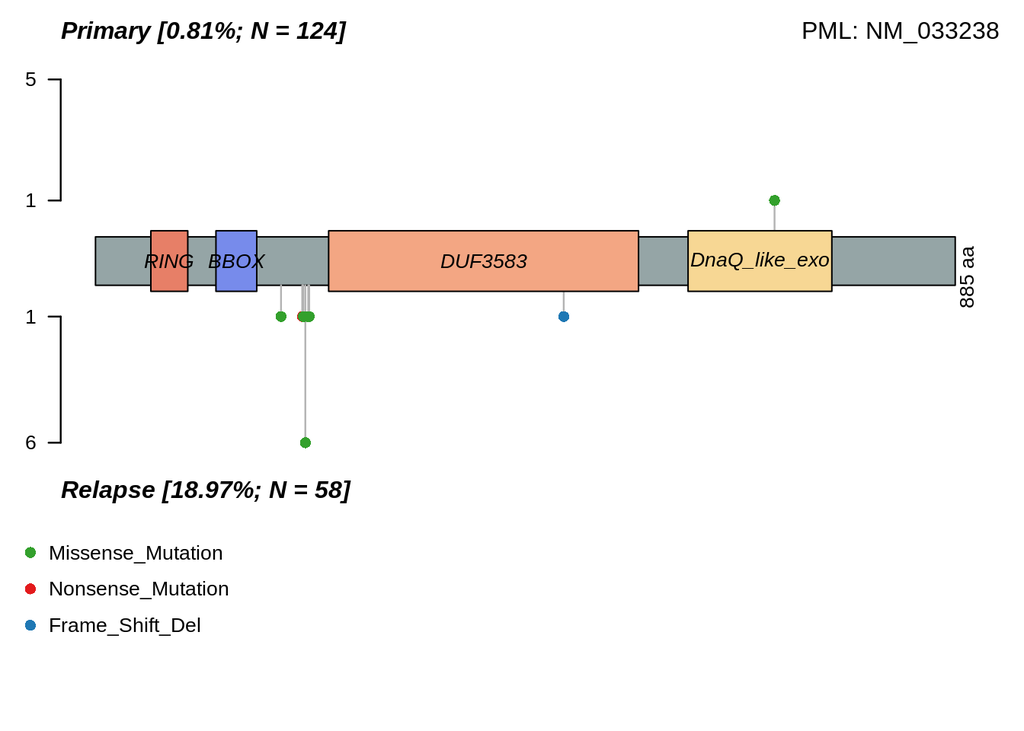

```r
lollipopPlot2(m1 = primary.apl, m2 = relapse.apl, gene = "PML", AACol1 = "amino_acid_change", AACol2 = "amino_acid_change", m1_name = "Primary", m2_name = "Relapse")
```

# 9.7 Clinical enrichment analysis Clinical Enrichment performs various groupwise and pairwise comparisions to identify enriched mutations for every category within a clincila feature.

```r
fab.ce = clinicalEnrichment(maf = laml, clinicalFeature = 'FAB_classification')
```

```
## Sample size per factor in FAB_classification:
```

```
##
## M0 M1 M2 M3 M4 M5 M6 M7
## 19 44 44 21 39 19  3  3
```

```r
#Results are returned as a list. Significant associations p-value < 0.05
fab.ce$groupwise_comparision[p_value < 0.05]
```

| Hugo_Symbol | Group1 | Group2 | n_mutated_group1 | n_mutated_group2 | p_value | OR_low | OR_high | fdr |
| --- | --- | --- | --- | --- | --- | --- | --- | --- |
| IDH1 | M1 | Rest | 11 of 44 | 7 of 149 | 0.0002597371 | 0 | 0.3926994 | 0.0308575 |
| TP53 | M7 | Rest | 3 of 3 | 12 of 190 | 0.0003857187 | 0 | 0.1315271 | 0.0308575 |
| DNMT3A | M5 | Rest | 10 of 19 | 38 of 174 | 0.0057610493 | 0 | 0.6406007 | 0.3072560 |
| CEBPA | M2 | Rest | 7 of 44 | 6 of 149 | 0.0117352110 | 0 | 0.6874270 | 0.3757978 |
| RUNX1 | M0 | Rest | 5 of 19 | 11 of 174 | 0.0117436825 | 0 | 0.6466787 | 0.3757978 |
| NPM1 | M5 | Rest | 7 of 19 | 26 of 174 | 0.0248582372 | 0 | 0.8342897 | 0.6628863 |
| CEBPA | M1 | Rest | 6 of 44 | 7 of 149 | 0.0478737468 | 0 | 0.9869971 | 1.0000000 |

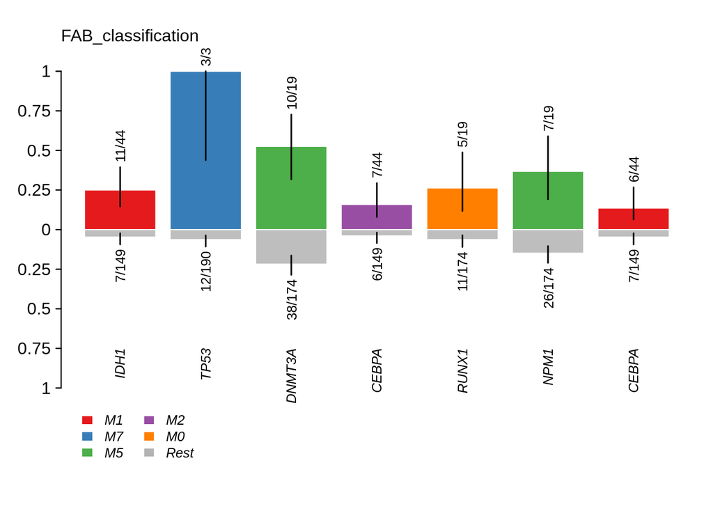

```r
plotEnrichmentResults(enrich_res = fab.ce, pVal = 0.05)
```

# 9.8 Drug-Gene Interactions drugInteractions function checks for drug–gene interactions and gene druggability information compiled from Drug Gene Interaction database.

```r
dgi = drugInteractions(maf = laml, fontSize = 0.75)
```

[figure not shown]

```r
dnmt3a.dgi = drugInteractions(genes = "DNMT3A", drugs = TRUE)
```

```
## Number of claimed drugs for given genes:
##      Gene N
## 1: DNMT3A 7
```

```r
#Printing selected columns.
dnmt3a.dgi[,.(Gene, interaction_types, drug_name, drug_claim_name)]
```

| Gene | interaction_types | drug_name | drug_claim_name |
| --- | --- | --- | --- |
| DNMT3A |  |  | N/A |
| DNMT3A |  | DAUNORUBICIN | Daunorubicin |
| DNMT3A |  | DECITABINE | Decitabine |
| DNMT3A |  | IDARUBICIN | IDARUBICIN |
| DNMT3A |  | DECITABINE | DECITABINE |
| DNMT3A | inhibitor | DECITABINE | CHEMBL1201129 |
| DNMT3A | inhibitor | AZACITIDINE | CHEMBL1489 |

# 9.9 Oncogenic Signaling Pathways

```r
OncogenicPathways(maf = laml)
```

```
## Pathway alteration fractions
```

```
##        Pathway  N n_affected_genes fraction_affected
##  1:    RTK-RAS 85               18        0.21176471
##  2:      Hippo 38                7        0.18421053
##  3:      NOTCH 71                6        0.08450704
##  4:        MYC 13                3        0.23076923
##  5:        WNT 68                3        0.04411765
##  6:       TP53  6                2        0.33333333
##  7:       NRF2  3                1        0.33333333
##  8:       PI3K 29                1        0.03448276
##  9: Cell_Cycle 15                0        0.00000000
## 10:   TGF-Beta  7                0        0.00000000
```

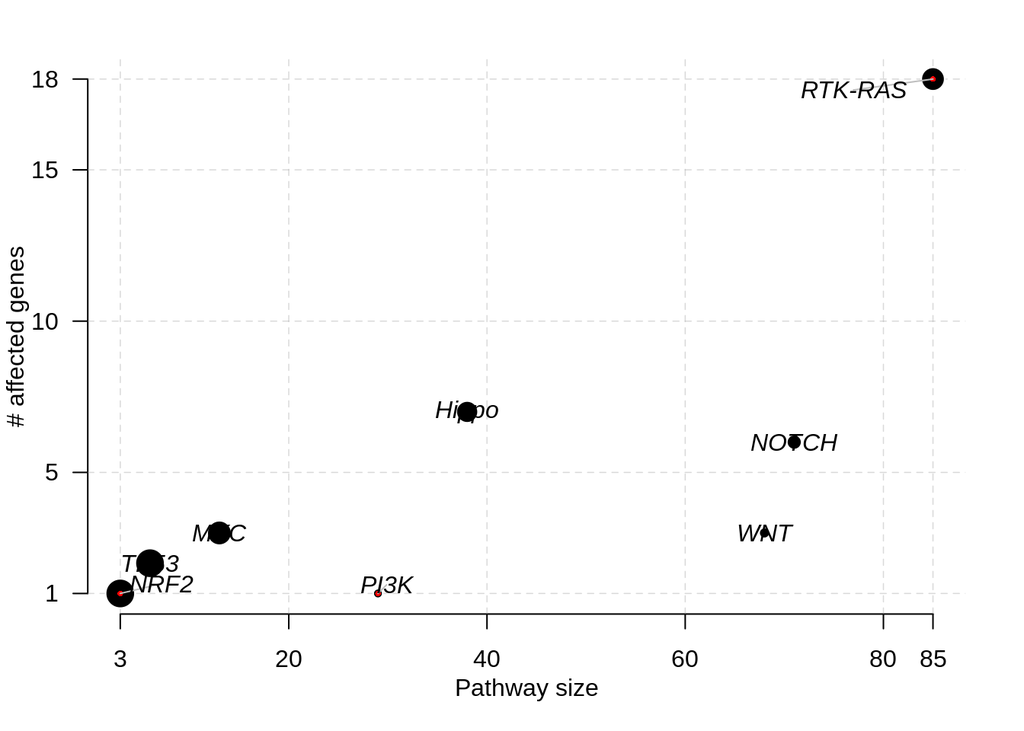

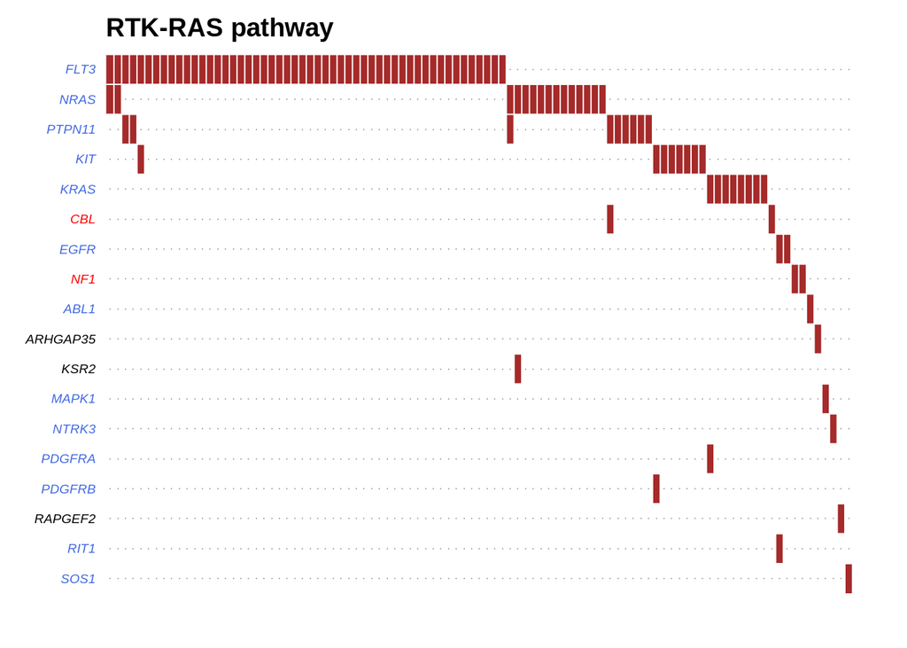

```r
PlotOncogenicPathways(maf = laml, pathways = "RTK-RAS")
```

# 9.11 Mutational Signatures signatures can be extracted by decomposing matrix of nucleotide substitutions, classified into 96 substitution classes based on immediate bases surrounding the mutated base.

```r
# BSgenome.Hsapiens.UCSC.hg19 package
#if (!requireNamespace("BiocManager", quietly = TRUE))
 #   install.packages("BiocManager")
#BiocManager::install("BSgenome.Hsapiens.UCSC.hg19")

# NMF and pheatmap packages
#install.packages(c("pheatmap", "NMF"))
```

```r
library(BSgenome.Hsapiens.UCSC.hg19, quietly = TRUE)
laml.tnm = trinucleotideMatrix(maf = laml, prefix = 'chr', add = TRUE, ref_genome = "BSgenome.Hsapiens.UCSC.hg19")
```

```
## -Extracting 5' and 3' adjacent bases
## -Extracting +/- 20bp around mutated bases for background C>T estimation
## -Estimating APOBEC enrichment scores
## --Performing one-way Fisher's test for APOBEC enrichment
## ---APOBEC related mutations are enriched in  3.315 % of samples (APOBEC enrichment score > 2 ;  6  of  181  samples)
## -Creating mutation matrix
## --matrix of dimension 188x96
```